## How-to

#### Auto-Regressive (AR) Model of order *p*

Before starting with defining an ARIMA model, we will start with some of the simple model’s it nests, untill we finally build up to the ARIMA. The AR model postulates that the value of the outcome variable, $X_t$, is formed by a linear combination of past values and a stochastic term:

$$X_t = \mu + \sum_{i = 1}^p \varphi_i X_{t-i} + \epsilon_t$$
where $\varphi_1,..., \varphi_p$ are the parameters of the model, $\mu$ is a constant and $\epsilon_t$ is white noise (~ $D(0,\sigma)$ i.i.d).

In order to estimate an AR model of order *p* we need to set all parameters of the ARIMA model to 0 except the parameter *p*, set at the desired value.

#### Moving-average (MA) Model of order *q*

The MA model postulates that the value of the outcome variable $X_t$, is a linear combination of current and past values of a stochastic term:

$$X_t = \mu + \epsilon_t + \sum_{i=1}^q \theta_i \epsilon_{t-i}$$

where $\theta_1,..., \theta_q$ are the parameters of the model, $\mu$ is a constant and $\epsilon_t,..., \epsilon_{t-q}$ are white nosie error tems.

In order to estimate an MA model of order *q* we need to set all parameters of the ARIMA model to 0 except the parameter *q*, set at the desired value.

#### Autoregressive-moving-average (ARMA) model

The ARMA model postulates that the value of the outcome variable $X_t$, is a linear combination of an AR and MA model:

$$X_t = \mu + \epsilon_t + \sum_{i = 1}^p \varphi_i X_{t-i} + \sum_{i=1}^q \theta_i \epsilon_{t-i}$$
In order to estimate an ARMA model of order *p*, *q* we need to set all parameters of the ARIMA model to 0 except parameters *p* and *q*, set at the desired value.

#### Autoregressive integrated moving average (ARIMA) model

The ARIMA postulates that the value of the outcome variable $X_t$, is a linear combination of an AR and MA model, along with differencing, *d* times, in order to make the original series stationary:

$$X_t = \mu -(\Delta^d X_t - X_t) + \sum_{i = 1}^p \varphi_i \Delta^d X_{t-i} + \sum_{i=1}^q \theta_i \epsilon_{t-i} + \epsilon_t$$

The ARIMA model can also be adjusted for seasonality, yielding the SARIMA model.

#### Example

Our data will be the inbuilt dataset in *R*, *AirPassangers*, a dataset consisting of total monthly international airline passangers from 1949 to 1960. We will fit an “optimal” ARIMA model by using the Box-Jenkins method (embeded in the “Box-Jenkins method” button) and forecast 12 months of data.

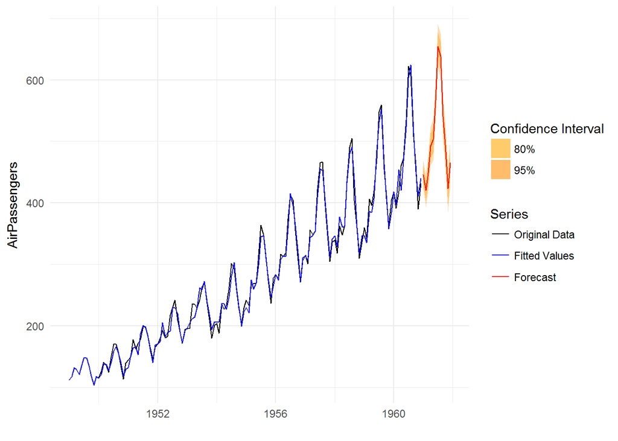

```
##
## Forecast method: ARIMA(2,1,1)(0,1,0)[12]
##
## Model Information:
## Series: AirPassengers
## ARIMA(2,1,1)(0,1,0)[12]
##
## Coefficients:
##          ar1     ar2      ma1
##       0.5960  0.2143  -0.9819
## s.e.  0.0888  0.0880   0.0292
##
## sigma^2 estimated as 132.3:  log likelihood=-504.92
## AIC=1017.85   AICc=1018.17   BIC=1029.35
##
## Error measures:
##                  ME     RMSE     MAE      MPE     MAPE     MASE
## Training set 1.3423 10.84619 7.86754 0.420698 2.800458 0.245628
##                     ACF1
## Training set -0.00124847
##
## Forecasts:
##          Point Forecast    Lo 80    Hi 80    Lo 95    Hi 95
## Jan 1961       445.6349 430.8903 460.3795 423.0851 468.1847
## Feb 1961       420.3950 403.0907 437.6993 393.9304 446.8596
## Mar 1961       449.1983 429.7726 468.6240 419.4892 478.9074
## Apr 1961       491.8399 471.0270 512.6529 460.0092 523.6707
## May 1961       503.3945 481.5559 525.2330 469.9953 536.7937
## Jun 1961       566.8624 544.2637 589.4612 532.3007 601.4242
## Jul 1961       654.2602 631.0820 677.4383 618.8122 689.7081
## Aug 1961       638.5975 614.9704 662.2246 602.4630 674.7320
## Sep 1961       540.8837 516.9028 564.8647 504.2081 577.5594
## Oct 1961       494.1266 469.8624 518.3909 457.0177 531.2356
## Nov 1961       423.3327 398.8381 447.8273 385.8715 460.7939
## Dec 1961       465.5076 440.8229 490.1923 427.7556 503.2596
```

Or, if you’re feeling a little bit lazy, just click the “Fit and Forecast” button as the default values and data are set to deliver our example plot.